# Pressing the (Dis)Advantage

From [538 Riddler: Can You Find The Best Dungeons & Dragons Strategy?](https://fivethirtyeight.com/features/can-you-find-the-best-dungeons-dragons-strategy/)

> The fifth edition of Dungeons & Dragons introduced a system of “advantage and disadvantage.” When you roll a die “with advantage,” you roll the die twice and keep the higher result. Rolling “with disadvantage” is similar, except you keep the lower result instead. The rules further specify that when a player rolls with both advantage and disadvantage, they cancel out, and the player rolls a single die. Yawn!

> There are two other, more mathematically interesting ways that advantage and disadvantage could be combined. First, you could have “advantage of disadvantage,” meaning you roll twice with disadvantage and then keep the higher result. Or, you could have “disadvantage of advantage,” meaning you roll twice with advantage and then keep the lower result. With a fair 20-sided die, which situation produces the highest expected roll: advantage of disadvantage, disadvantage of advantage or rolling a single die?

> Extra Credit: Instead of maximizing your expected roll, suppose you need to roll N or better with your 20-sided die. For each value of N, is it better to use advantage of disadvantage, disadvantage of advantage or rolling a single die?

First I’ll have a look at the conventional rolls: rolling a single die, rolling with advantage, rolling with disadvantage.

```r
N <- 1000000
roll1 <- sample(1:20, N, replace=T)
roll2 <- sample(1:20, N, replace=T)
raw_rolls <- data.frame(advantage=pmax(roll1, roll2), single=roll1, disadvantage=pmin(roll1, roll2))
summary(raw_rolls)
```

```
##    advantage         single      disadvantage
##  Min.   : 1.00   Min.   : 1.0   Min.   : 1.00
##  1st Qu.:10.00   1st Qu.: 5.0   1st Qu.: 3.00
##  Median :15.00   Median :11.0   Median : 6.00
##  Mean   :13.83   Mean   :10.5   Mean   : 7.17
##  3rd Qu.:18.00   3rd Qu.:15.0   3rd Qu.:10.00
##  Max.   :20.00   Max.   :20.0   Max.   :20.00
```

The mean of the single roll is close to the expected 10.5. I’m not sure what I expect for advantage and disadvantage rolls, beyond the simple intuition that they are better/worse than a single roll, and that checks out here, with about 13.8 for advantage, 7.2 for disadvantage.

How about a visualization? Histograms of the simulation results approximate the probability mass functions.

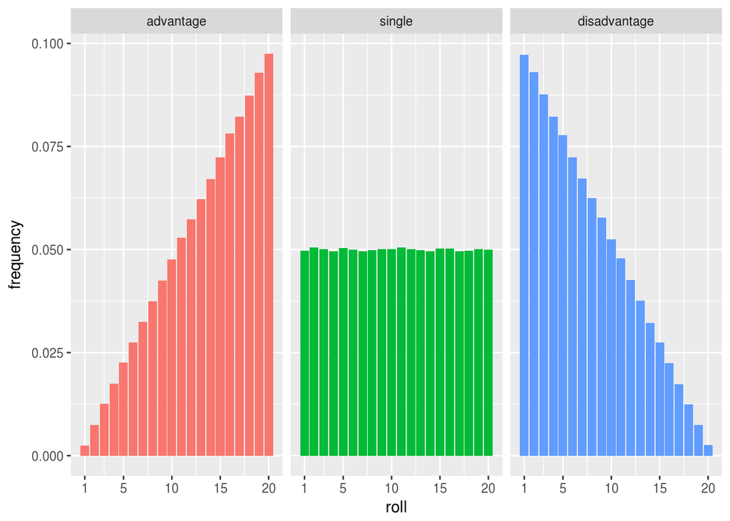

```r
rolls <- melt(raw_rolls, id.vars=NULL)
names(rolls) <- c("type", "roll")
# re-order the factor so things are ordered left-to-right, best-to-worst
rolls$type <- factor(rolls$type, levels=c("advantage", "single", "disadvantage"))
roll_pmf <- rolls %>% group_by(type, roll) %>% summarize(count=n()) %>% mutate(frequency=count/sum(count))

p <- ggplot(roll_pmf, aes(x=roll, y=frequency, fill=type)) +
  geom_bar(stat="identity", show.legend=F) +
  scale_x_continuous(breaks=c(1, 5, 10, 15, 20))
p + facet_grid(. ~ type)
```

Interesting: the most likely result on an advantage roll is 20, and on a disadvantage roll it’s 1.

Another way to look at the probabilties is with a boxplot. This shows the median, 25th, and 75th percentile. The expected value is marked with a diamond.

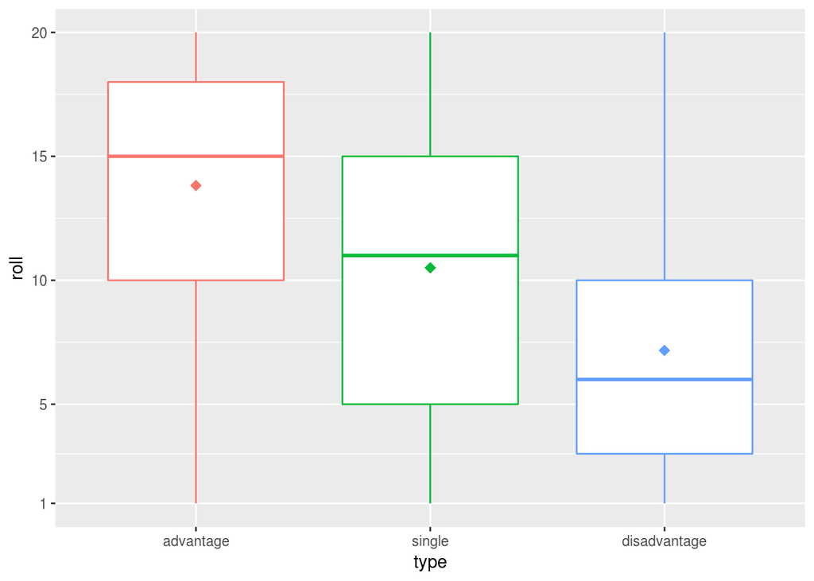

```r
ggplot(rolls, aes(type, roll, color=type)) +
  geom_boxplot(show.legend=F) +
  stat_summary(fun.y=mean, geom="point", shape=18, size=3, show.legend=F) +
  scale_y_continuous(breaks=c(1, 5, 10, 15, 20))
```

Enough tinkering! For an advantage-of-disadvantage roll, you roll with disadvantage twice, and take the max. That’s 4 single rolls. Disadvantage-of-advantage is the same, with disadvantage and advantage, min and max swapped.

I’ll do 4 single rolls, and then reduce them down in two different ways to do advantage-of-disadvantage, disadvantage-of-advantage. I’ll keep the first single roll for comparison against the other two distributions.

```r
roll1 <- sample(1:20, N, replace=T)
roll2 <- sample(1:20, N, replace=T)
roll3 <- sample(1:20, N, replace=T)
roll4 <- sample(1:20, N, replace=T)
raw_rolls <- data.frame(
  disadvantage_of_advantage=pmin(pmax(roll1, roll2), pmax(roll3, roll4)),
  single=roll1,
  advantage_of_disadvantage=pmax(pmin(roll1, roll2), pmin(roll3, roll4))
)
summary(raw_rolls)
```

```
##  disadvantage_of_advantage     single     advantage_of_disadvantage
##  Min.   : 1.00             Min.   : 1.0   Min.   : 1.000
##  1st Qu.: 8.00             1st Qu.: 6.0   1st Qu.: 6.000
##  Median :11.00             Median :11.0   Median :10.000
##  Mean   :11.17             Mean   :10.5   Mean   : 9.836
##  3rd Qu.:15.00             3rd Qu.:16.0   3rd Qu.:13.000
##  Max.   :20.00             Max.   :20.0   Max.   :20.000
```

Now I can answer the first question:

> With a fair 20-sided die, which situation produces the highest expected roll: advantage of disadvantage, disadvantage of advantage or rolling a single die?

Answer: disadvantage-of-advantage is best, with an expected value around 11.2. A single roll is the next best choice, with an expected value of 10.5. Last place goes to advantage-of-disadvantage, with an expected value around 9.8.

What do the approximate probability mass functions look like?

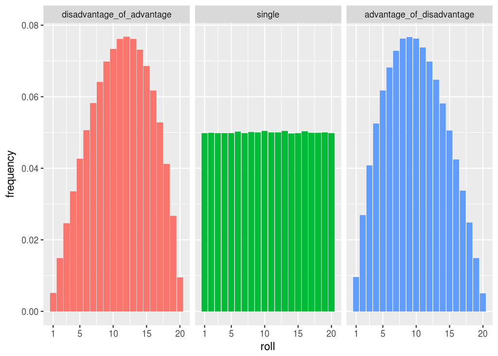

```r
rolls <- melt(raw_rolls, id.vars=NULL)
names(rolls) <- c("type", "roll")
# re-order the factor so things are ordered left-to-right, best-to-worst
rolls$type <- factor(rolls$type, levels=c("disadvantage_of_advantage", "single", "advantage_of_disadvantage"))

roll_pmf <- rolls %>% group_by(type, roll) %>% summarize(count=n()) %>% mutate(frequency=count/sum(count))

p <- ggplot(roll_pmf, aes(x=roll, y=frequency, fill=type)) +
  geom_bar(stat="identity", show.legend=F) +
  scale_x_continuous(breaks=c(1, 5, 10, 15, 20))
p + facet_grid(. ~ type)
```

Both disadvantage-of-advantage and advantage-of-disadvantage cluster in the middle, centered around 10 or so. If you’re betting on rolling a 20 (or a 1), go with a single roll.

As a cross-check, boxplots confirm the answer, and highlight how much closer all three choices are to one another, compared to conventional advantage and disadvantage rolls.

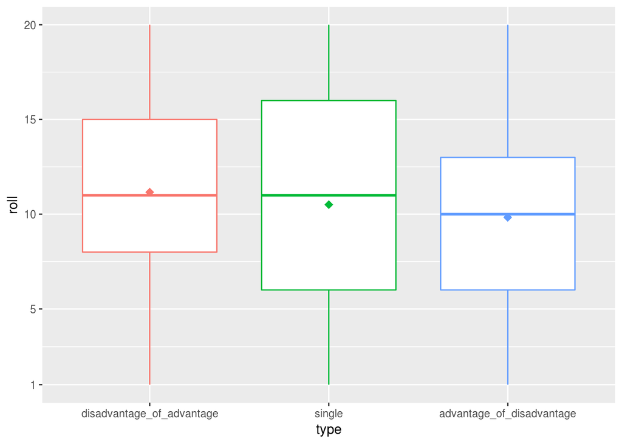

```r
ggplot(rolls, aes(type, roll, color=type)) +
  geom_boxplot(show.legend=F) +
  stat_summary(fun.y=mean, geom="point", shape=18, size=3, show.legend=F) +
  scale_y_continuous(breaks=c(1, 5, 10, 15, 20))
```

How about that extra credit question?

> Instead of maximizing your expected roll, suppose you need to roll N or better with your 20-sided die. For each value of N, is it better to use advantage of disadvantage, disadvantage of advantage or rolling a single die?

The simulated probability mass functions answer this one. For example, if we need to roll 19 or higher, the odds of success are the probability of rolling a 19, plus the odds of rolling a 20, for each of the three roll types. We’ll calculate all the odds with a cumulative sum, from 20 downward.

Sanity checks/expectations: for each roll type, we expect to see 100% success if N=1. As N increases, the odds of success decrease, down to the minimum at 20 (the odds of getting 20, for each type).

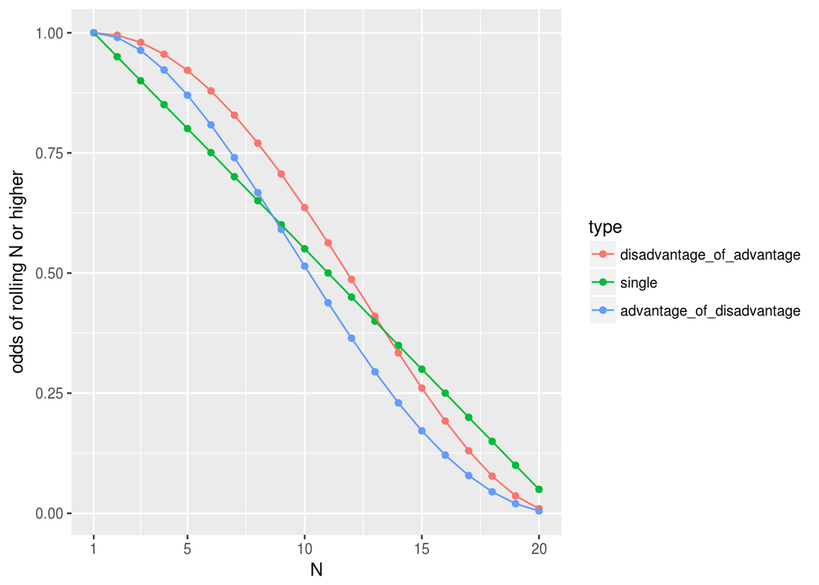

```r
roll_pmf <- roll_pmf %>% mutate(rcdf = rev(cumsum(rev(frequency))))
p <- ggplot(roll_pmf, aes(x=roll, y=rcdf, color=type)) +
  geom_point() +
  geom_line() +
  scale_x_continuous(breaks=c(1, 5, 10, 15, 20))
p + xlab("N") + ylab("odds of rolling N or higher")
```

Advantage-of-disadvantage is only an optimal choice when N=1 (you need to roll 1 or higher - not an interesting situation!). It’s vacuous: all 3 choices give the same “odds”. Otherwise, chose disadvantage-of-advantage for N up to 13, and choose single roll for N=14 and higher.

Source code is [here](https://github.com/aaronferrucci/dnd_vantage)